# Technological change

**NOTE**: The present notebook is coded in R. It relies heavily on the [**tidyverse**](https://www.tidyverse.org/) ecosystem of packages. We load the tidyverse below as a prerequisite for the rest of the notebook - along with a few other libraries.

$\rightarrow$ Don’t forget that code flows **sequentially**. A random chunk may not work if the previous have have not been executed.

```r
library(tidyverse)    # Package for data wrangling
library(readxl)       # Package to import MS Excel files
library(latex2exp)    # Package for LaTeX expressions
library(quantmod)     # Package for stock data extraction
library(highcharter)  # Package for reactive plots
library(patchwork)    # Package for plotting layout
library(ggcorrplot)   # Package for correlation plots
library(ggrepel)      # Package for neat annotations
library(plm)          # Package for panel models
library(WDI)          # Package for World Bank data
library(broom)        # Package for neat regression output
impute <- function(v, n = 6){     # Imputation function
  for(j in 1:n){
    ind <- which(is.na(v))
    if(length(ind)>0){
      if(ind[1]==1){ind <- ind[-1]}
      v[ind] <- v[ind-1]
    }
  }
  return(v)
}
```

The content of the notebook is heavily inspired from the book [**Advanced Macro-economics - An Easy Guide**](https://press.lse.ac.uk/site/books/m/10.31389/lsepress.ame/).

# Context & motivation

It’s not easy to explain growth **endogenously**. Adding new factors (human capital) to the production function does not help if CRS are assumed.

How about **technology**? This could be an interesting factor: a country with access to advanced technologies should be able to improve productivity and be more competitive, both **in time** and **in comparison with other countries**.

Look at the **pace of innovation** below!

[figure not shown]

All signs point to a rapid increase. See for instance **patents**! (though patents do not mean much per se - without more data on their usefulness).

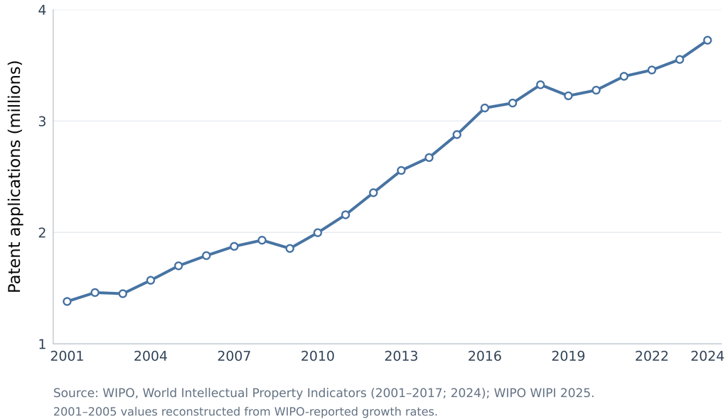

We first refer to a recent piece on the drivers of productivity in manufacturing: [Why Is Manufacturing Productivity Growth So Low?](https://papers.ssrn.com/sol3/papers.cfm?abstract_id=5515863). Therein, the authors report: “*while productivity growth slowdowns are observed in multiple manufacturing industries, most of the measured sector-wide stagnation is quantitatively explained by productivity changes in Computer and Electronic Products Manufacturing (NAICS 334). In fact, nearly all of the manufacturing sector’s productivity growth since 1987—and its deceleration since 2009—can be attributed to this single 3-digit industry.*”

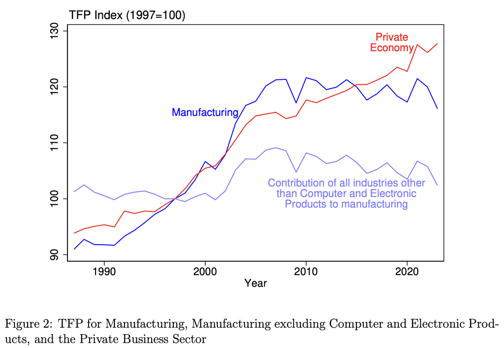

But: what does the (World Bank) data say for the aggregate economy, knowing that, in developed countries, the manufacturing sector has **considerably shrunk** and represents a minority of output? It’s not obvious to proxy for technology. To introduce new variables from the World Bank datasets, we will focus below on R&D (as % of GDP) and researchers (counted per million inhabitants).

## In the cross-section

Can technology-related variables explain difference of growth/wealth between countries?

```r
wb_growth <- WDI(                           # World Bank data
  indicator = c(
    "labor" = "SL.TLF.TOTL.IN",             # Labor force (# individuals)
    "pop" = "SP.POP.TOTL",                  # Population
    "gdp_percap" = "NY.GDP.PCAP.CD",        # GDP per capita
    "high_tech_exp" = "TX.VAL.TECH.MF.ZS",  # High tech exports (%)
    "patent_app" = "IP.PAT.RESD",           # Patent applications => need to be scaled
    "R_D" = "GB.XPD.RSDV.GD.ZS",            # R&D (%GDP)
    "nb_researchers" = "SP.POP.SCIE.RD.P6", # Nb researchers per million inhab.
    "gdp" = "NY.GDP.MKTP.CD"                # Gross Domestic Product (GDP)
  ),
  extra = TRUE,
  start = 1960,
  end = 2024) |>
  mutate(across(everything(), as.vector)) |>
  select(-status, -lending, -iso2c, -iso3c) |>
  filter(region != "Aggregates", income != "Aggregates") |>
  arrange(country, year) |>
  group_by(country) |>
  mutate(across(everything(), impute)) |>
  mutate(gdp_growth = gdp_percap/dplyr::lag(gdp_percap) - 1) |>
  ungroup() |>
  filter(lastupdated == max(lastupdated))
```

Let us visualize the link between growth and these two variables.

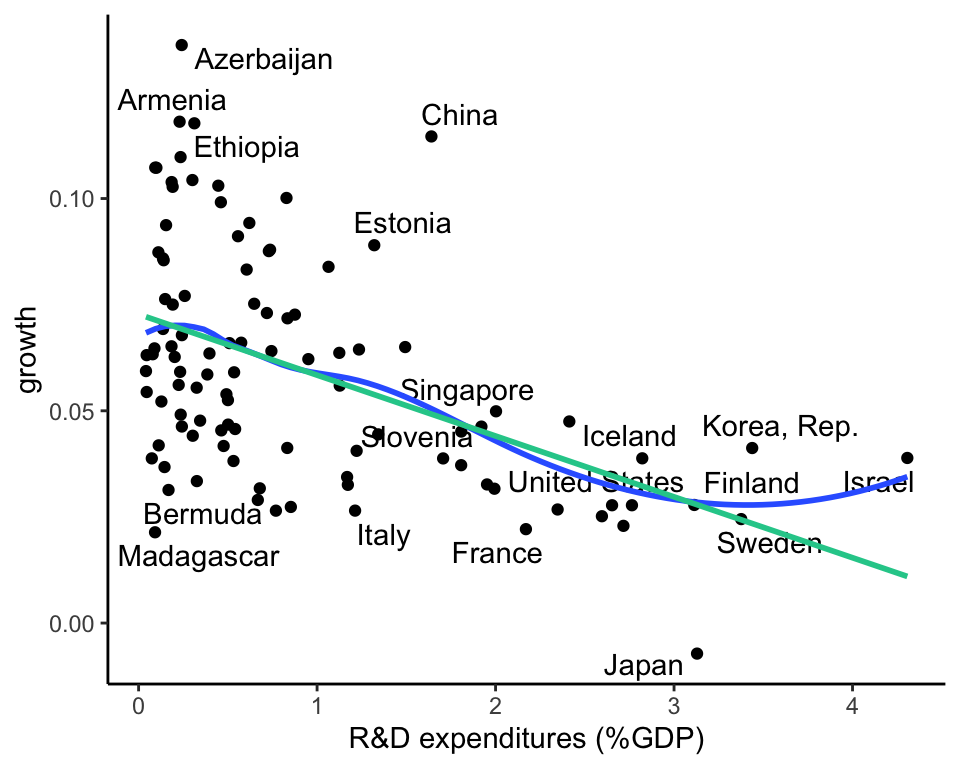

```r
wb_growth |>
  filter(is.finite(R_D), is.finite(gdp_growth)) |>
  group_by(country) |>
  mutate(n = n()) |>
  filter(n > 18) |>
  summarise(RD = mean(R_D, na.rm = T),
            growth = mean(gdp_growth)) |>
  ggplot(aes(x = RD, y = growth)) + geom_point() +
  theme_classic() + xlab("R&D expenditures (%GDP)") +
  geom_text_repel(aes(label = country)) +
  geom_smooth(se = F) + geom_smooth(method = "lm", se = F, color = "#22CC99")
```

The link is either far from obvious, or potentially negative, which is not what we would expect, intuitively…

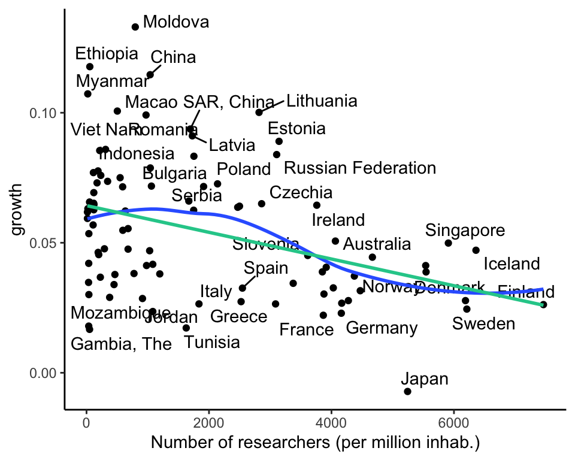

```r
wb_growth |>
  filter(is.finite(nb_researchers), is.finite(gdp_growth)) |>
  group_by(country) |>
  mutate(n = n()) |>
  filter(n > 15) |>
  summarise(nb_R = mean(nb_researchers, na.rm = T),
            growth = mean(gdp_growth)) |>
  ggplot(aes(x = nb_R, y = growth)) + geom_point() +
  theme_classic() + xlab("Number of researchers (per million inhab.)") +
  geom_text_repel(aes(label = country)) +
  geom_smooth(se = F) + geom_smooth(method = "lm", se = F, color = "#22CC99")
```

Same conclusion here… not very convincing!  
**High technology exports** (as % of manufactured exports) => to do in class!

## Time-series

Let us now turn to single-country time-related links.
We estimate the following model:
$$\Delta GDP_{t+1} = a + b X_t+ e_{t+1},$$
where $X_t$ is the variable of interest and $\Delta GDP$ is in fact growth of GDP **per capita**.

For simplicity, we test the case of the US only, but it’s easy (codewise) to adapt to other countries.

```r
lm(gdp_growth ~ lag(R_D), data = wb_growth |> filter(country == "United States")) |> tidy()
```

| term | estimate | std.error | statistic | p.value |
| --- | --- | --- | --- | --- |
| (Intercept) | -0.0057500 | 0.0372487 | -0.1543688 | 0.8784671 |
| lag(R_D) | 0.0157893 | 0.0130934 | 1.2058905 | 0.2383212 |

```r
lm(gdp_growth ~ lag(nb_researchers), data = wb_growth |> filter(country == "United States")) |> tidy()
```

| term | estimate | std.error | statistic | p.value |
| --- | --- | --- | --- | --- |
| (Intercept) | -0.0214014 | 0.0377856 | -0.5663892 | 0.5758074 |
| lag(nb_researchers) | 0.0000156 | 0.0000097 | 1.6054824 | 0.1200220 |

The link is positive but weak with **R&D**.  
It is also positive and slightly stronger (though not “strong”) with the **number of researchers**.  
All in all, the evidence is not overwhelmingly compelling.

What if we look at **variations**?

```r
lm(gdp_growth ~ lag(D_R_D),
   data = wb_growth |>
     filter(country == "United States") |>
     mutate(D_R_D = R_D / dplyr::lag(R_D) - 1)) |> tidy()
```

| term | estimate | std.error | statistic | p.value |
| --- | --- | --- | --- | --- |
| (Intercept) | 0.0413859 | 0.0056433 | 7.333675 | 0.0000001 |
| lag(D_R_D) | -0.1987537 | 0.1967447 | -1.010211 | 0.3217037 |

Not particularly convincing, either… (and with a negative sign!)

Let us now turn fo **theoretical** models.  
Many models seek to distill technological change in “equilibrium growth”, but many of them are quite sophisticated and hence out of the scope of an introductory course. We nonetheless present several approaches below.

## Back to Solow?

Recall a Cobb-Douglas production function, $y=Ak^\alpha$. Suppose now that **technology** allows $A$ to grow, i.e., $\dot{A}_t/A_t=\gamma_A$ ($A_t=A_0e^{\gamma_A t}$). Then,

$$\dot{y}_t= \dot{A}_t k_t^\alpha + A_t\alpha \dot{k}_tk_t^{\alpha-1}$$

and
$$\frac{\dot{y}_t}{y_t}= \frac{\dot{A}_t}{A_t}+\alpha \frac{\dot{k}_t}{k_t}=\gamma_A + \alpha \gamma_k.$$
The trick is that technology does not enter the **budget constraint** (unlike capital). This is why it can have a nonzero growth rate upon equilibrium. Capital remains constant, but technology grows indefinitely.

This is *cheating*, i.e., growth is **exogenous**.

# A seemingly segmented economy

One possible “way out” is to posit a novel form of the production function. Here we follow Romer’s [Endogenous Technological Change](https://www.journals.uchicago.edu/doi/abs/10.1086/261725). Originally, the model assumes a **variety of products**, $X(i)$ - $i$ being the index. Now, there are also different types of products: the final ones and the intermediate (or raw) ones, which serve as inputs for final output. $X(i)$ refers to the quantity of intermediate input of variety $i$ used by the economy. But in fact, in the end (as we’ll see), the only thing that matters is the dichotomy between intermediate products and the final output. Indeed, the production function is seemingly more intricate:

$$Y(X)=\left(\int_0^M X(i)^\alpha di \right)^{1/\alpha}, \quad \alpha \in (0,1)$$
where $M$ is the range of varieties (basically, the integral is a sum). Another way to see this is to imagine sectors that are infinitely small (hence the integral). Labor is left out to ease the computations - but can also be viewed as already incorporated in the $X(i)$.

The firms that produce the final output take the prices of intermediate products ($p(i)$) as given. They seek to minimize costs for a given unit of good produced, i.e.,

$$\min_{X(i)} \int_0^Mp(i)X(i)di, \quad s.t. \quad \int_0^MX(i)^\alpha di=1 \tag{1}$$

The Lagrange formulation is

$$L=\int_0^Mp(i)X(i)di - \lambda \left(\int_0^MX(i)^\alpha di-1 \right)$$

and

$$\frac{\partial L}{\partial X(i)}=p(i)-\lambda \alpha X(i)^{\alpha-1}$$

so that the FOCs lead to
$$X(i)=\left(\frac{\alpha \lambda}{p(i)} \right)^{1/(1-\alpha)}.$$

Demand is logically **downward sloping**: if variety $i$ costs more, then demand for it will shrink (we exclude the case of [Giffen](https://en.wikipedia.org/wiki/Giffen_good) and [Veblen](https://en.wikipedia.org/wiki/Veblen_good) goods).

But in fact, upon a simplifying assumption on the lack of heterogeneity in the cross-section of intermediate products, **the distinction vanishes**. Indeed, upon setting $X(i)=Z/M$ where $Z$ represents the total resources required to produce the intermediate inputs, we get

$$Y=(M(Z/M)^\alpha)^{1/\alpha}=ZM^{1/\alpha-1},$$

which, from the perspective of $Z$, is equivalent to the $AK$ model.

Importantly, the varieties are not fixed once and for all; they may change, due to innovations and R&D. Hence, while $Z$ is fixed, $M$ is not and for simplicity, we assume $\dot{M}_t=\gamma_M M_t$ (i.e., $M_t=M_0e^{\gamma_M t}$ with $\gamma_M>0$). It holds that

$$\dot{Y}_t=Z\dot{M}_t (1/\alpha-1)M_t^{1/\alpha-2}$$
so

$$\frac{\dot{Y}_t}{Y_t}=(1/\alpha-1)\frac{\dot{M}_t}{M_t}=(1/\alpha-1)\gamma_M >0 \quad \text{if} \quad \alpha \in (0,1).$$
In the original paper, $\gamma_M$ depends on $\alpha$, on labor and, crucially, on the **productivity of innovation**. It is linearly increasing in the latter two variables.

# Semi-endogenous growth

Here we follow [**R&D-based models of economic growth**](https://www-leland.stanford.edu/~chadj/JonesJPE95.pdf), by Jones.

Here, the total labor force is split in two: $L_Y$ for the labor that directly produces output and $L_A$ for the workforce that works in R&D… The production function is

$$Y=K^{1-a}(AL_Y)^a,$$
and the interesting part here is the evolution of $A$, which is defined as the **productivity of knowledge**. We know that specifying $\dot{A}/A=\delta$ is cheating as this leads to **exogenous** growth. Instead, suppose
$$\dot{A}=\tilde{\delta} L_A^\lambda, \quad \lambda \in (0,1],$$
i.e., change in innovation is driven by the R&D headcount but possibly at a power smaller than one. $\tilde{\delta}$ is the rate at which “scientists” discover new ideas and products. This rate could depend on the level of knowledge in the economy. Here we assume that
$$\tilde{\delta}=\delta A^\phi, \quad \phi \in (0,1)$$
where $\phi$ determines the returns of **knowledge**. In the end,
$$\dot{A}=\delta A^\phi L_A^\lambda \quad \Leftrightarrow \quad \gamma_A= \frac{\dot{A}}{A}=\delta A^{\phi-1}L_A^\lambda.$$
If we differentiate with respect to $t$, we get
$$\frac{\partial \gamma_A}{\partial t}=\delta(\lambda L_A^{\lambda-1}A^{\phi-1}\dot{L}_A+\dot{A}(\phi-1)A^{\phi-2}L_A^\lambda).$$
If the growth rate of $A$ remains constant, this means the above quantity is zero, i.e.,
$$\frac{\lambda}{1-\phi}\frac{\dot{L_A}}{L_A}=\frac{\dot{A}}{A}.$$
If the growth rate of $L_A$ is $n$, then we have
$$\gamma_A=\frac{\lambda n}{1-\phi}, \tag{2}$$
hence the parameter $\phi$ plays a crucial role. This is all the more evident if we recall that under standard assumptions, it holds that (generic) production factors follow dynamics such as:
$$\gamma_x= \frac{\dot{x}_t}{x_t}=s\frac{y_t}{x_t}-(\delta+n),$$
hence if $\gamma_x$ is constant, it means that the ratio $y_t/x_t$ should be constant too, i.e., that all quantities grow at the same rate, which will be given by Equation 2 in the model. A strictly positive growth requires $\lambda>0$ and $n>0$ - the latter being less and less obvious recently (post 2025).

# Technology diffusion (in the cross-section)

The models above focus on the **creation** of new ideas. But an innovation does not raise productivity everywhere as soon as it appears. It must also be **adopted**. We now consider a simple diffusion approach, in the spirit of [Comin and Hobijn](https://www.nber.org/papers/w11928), who document large differences across countries in the adoption of a wide range of technologies. See also [Technology Usage Lags](https://link.springer.com/article/10.1007/s10887-008-9035-5) from the same authors.

Let $A_t^*$ denote the **productivity frontier** and let $m_{i,t}\in[0,1]$ measure how much of the frontier technology has been adopted in country $i$. A simple representation of local productivity is

$$\log A_{i,t}=(1-m_{i,t})\log A_{i,t-1}+m_{i,t}\log A_t^*.$$

A country that adopts more rapidly closes the gap with the frontier more quickly. One simple way to represent the diffusion of a new technology is the S-shaped adoption curve:

$$\dot{m}_{i,t}=\kappa m_{i,t}(1-m_{i,t}), \qquad \kappa>0.$$

For instance, see the code below.

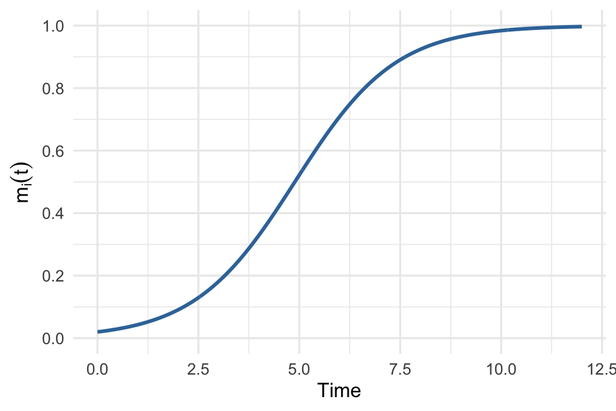

```r
kappa <- 0.8
dt <- 0.02
df <- data.frame(t = seq(0, 12, by = dt), m = NA)
df$m[1] <- 0.02
for (j in 2:nrow(df)) {
  m <- df$m[j - 1]
  df$m[j] <- m + dt * kappa * m * (1 - m)
}
ggplot(df, aes(t, m)) +
  geom_line(color = "#3976A8", linewidth = 1.2) +
  scale_y_continuous(limits = c(0, 1), breaks = seq(0, 1, 0.2)) +
  labs(x = "Time", y = expression(m[i](t))) +
  theme_minimal(base_size = 14)
```

This is not too far fetched if we take a long term perspective:

[figure not shown]

Though for online services and social media, the speed is much faster…

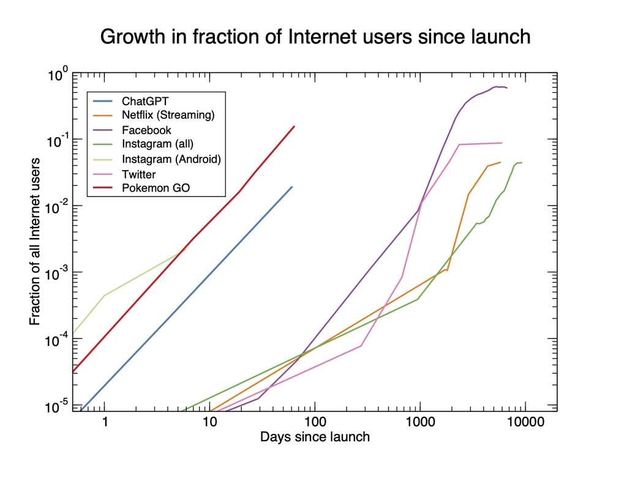

Output per worker still depends on capital, but now also on local productivity:

$$y_{i,t}=A_{i,t}k_{i,t}^{\alpha}, \qquad \alpha\in(0,1).$$

This is deliberately a small model: **innovation** moves the frontier, while **diffusion** determines how quickly each country benefits from it. For an illustration, we use internet use as a proxy for the adoption of digital technology. It is an imperfect proxy, but the data are public and available for many countries.

```r
tech_diffusion <- WDI(
  indicator = c(
    "gdp_percap" = "NY.GDP.PCAP.PP.KD", # GDP per capita, constant PPP dollars
    "internet" = "IT.NET.USER.ZS"       # Individuals using the Internet (% population)
  ),
  start = 1990,
  end = 2024
) |>
  filter(!is.na(gdp_percap), !is.na(internet)) |>
  arrange(country, year) |>
  group_by(country) |>
  mutate(
    gdp_growth = if_else(
      year == dplyr::lag(year) + 1,
      log(gdp_percap) - log(dplyr::lag(gdp_percap)),
      NA_real_
    ),
    internet_change = if_else(
      year == dplyr::lag(year) + 1,
      internet - dplyr::lag(internet),
      NA_real_
    )
  ) |>
  ungroup()
```

The adoption curve is often S-shaped: take-up can be slow at first, accelerate, and then flatten as it approaches saturation. The following plot shows internet use for a few economies.

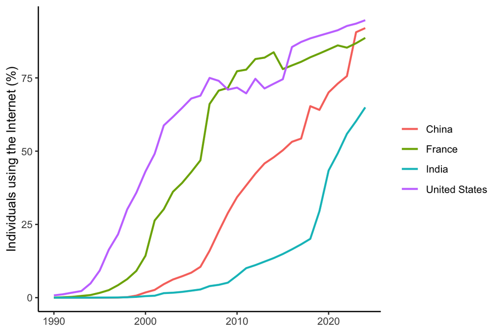

```r
tech_diffusion |>
  filter(country %in% c("France", "India", "United States", "China")) |>
  ggplot(aes(x = year, y = internet, colour = country)) +
  geom_line(linewidth = 0.8) +
  theme_classic() +
  labs(x = NULL, y = "Individuals using the Internet (%)", colour = NULL)
```

Finally, we compare changes in internet use with GDP-per-capita growth across countries. The relationship need not be positive in every period: adoption is measured imperfectly, and growth of course reflects many other forces. The plot however shows a very limited relationship…

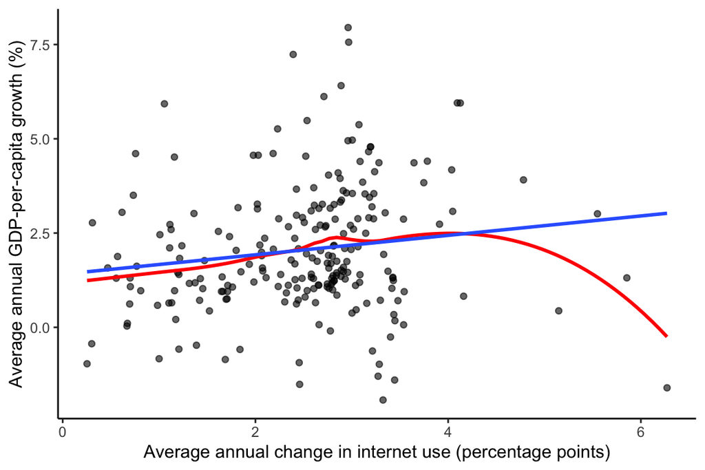

```r
tech_diffusion |>
  filter(is.finite(gdp_growth), is.finite(internet_change)) |>
  group_by(country) |>
  summarise(
    growth = mean(gdp_growth, na.rm = T) * 100,
    adoption = mean(internet_change, na.rm = T),
    .groups = "drop"
  ) |>
  ggplot(aes(x = adoption, y = growth)) +
  geom_point(alpha = 0.6) + geom_smooth(se = F, color = "red") +
  theme_classic() + geom_smooth(method = "lm", se = F) +
  labs(x = "Average annual change in internet use (percentage points)",
       y = "Average annual GDP-per-capita growth (%)")
```

# The productivity J-curve

The diffusion section above considers how a technology **spreads**. We now consider why its productivity gains may take time to appear. General-purpose technologies (GPTs!) such as electricity, computers or AI require complementary investments: firms need to adapt their infrastructure, software, data, skills, and work processes before the technology is used effectively. This is the focus of [Brynjolfsson, Rock, and Syverson (2021)](https://www.aeaweb.org/articles?id=10.1257/mac.20180386).

Here, $B_t$ is a stock of complementary intangible assets. It can include:

- **Software and data infrastructure**: databases, pipelines, and systems that connect the technology to the firm’s operations.
- **Process redesign**: changing how orders are handled, decisions are made, tasks are divided between people and machines.
- **Firm-specific skills**: training employees to use the technology and check its output.
- **Organizational capital**: new routines and management practices that let the technology be used productively.

Not all intangible investment is missing from measured output. For example, U.S. national accounts capitalize business R&D and software, just like entertainment, literary, and artistic works. The BEA’s [intellectual-property investment data](https://www.bea.gov/data/special-topics/intellectual-property) documents these assets.

A simple production and accumulation block is

$$Y_t^* = G_t K_t^\alpha L_t^{1-\alpha} B_t^\eta,
\qquad \alpha,\eta>0,$$

$$\dot B_t = I_t^B-\delta_B B_t,
\qquad I_t^{B,U}=\theta I_t^B,
\qquad 0\leq\theta\leq1,$$

where $I_t^B$ is investment in complementary assets and $I_t^{B,U}$ is the portion not captured in the accounts. Measured output and measured TFP can then be represented schematically as

$$Y_t^{\mathrm{meas}}\approx Y_t^*-I_t^{B,U},
\qquad
A_t^{\mathrm{meas}}=\frac{Y_t^{\mathrm{meas}}}{K_t^\alpha L_t^{1-\alpha}}.$$

Early on, measured productivity can understate the technological gains because benefits have **not yet** accumulated. Later on, the assets end up rising output, and measured productivity growth can overstate the gains because the intangibles are **not accounted for**. Brynjolfsson, Rock, and Syverson find substantial J-curve effects for software but smaller effects for computer hardware. Their adjustment for computer-related intangibles raises the U.S. TFP level relative to official measures.

We propose a stylize simulation below It shows an initial dip in measured TFP relative to its pre-implementation level, followed by a later increase.

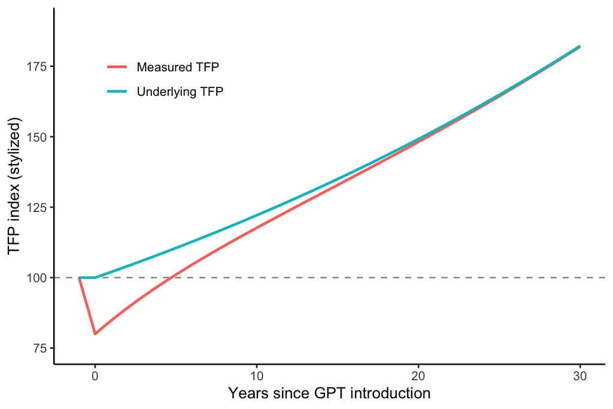

```r
jcurve <- tibble(t = seq(0, 30, by = 0.1)) |>
  mutate(
    investment = exp(-0.15 * t),
    true_tfp = 100 * exp(0.02 * t),
    measured_tfp = true_tfp - 20 * investment
  ) |>
  bind_rows(tibble(
    t = -1, investment = 0,
    true_tfp = 100, measured_tfp = 100
  )) |>
  arrange(t)

jcurve |>
  pivot_longer(c(true_tfp, measured_tfp),
               names_to = "series", values_to = "tfp") |>
  mutate(series = recode(
    series,
    true_tfp = "Underlying TFP",
    measured_tfp = "Measured TFP"
  )) |>
  ggplot(aes(x = t, y = tfp, colour = series)) +
  geom_hline(yintercept = 100, linetype = "dashed", colour = "grey60") +
  geom_line(linewidth = 0.9) +
  coord_cartesian(ylim = c(75, 190)) +
  theme_classic() + theme(legend.position = c(0.2,0.8)) +
  labs(x = "Years since GPT introduction",
       y = "TFP index (stylized)",
       colour = NULL)
```

## A balanced-growth extension

The J-curve model above describes the transition and the measurement of productivity. To obtain a balanced-growth path, we add investment in physical capital and complementary assets. After the new technology arrives, we fix its level $G$ and labor $L$ to a constant. Suppose fixed shares $s_K$ and $s_B$ of output are invested in physical capital and intangible complements, and the remainder is consumed:

$$Y_t=G K_t^\alpha L^{1-\alpha}B_t^\eta,
\qquad C_t=(1-s_K-s_B)Y_t,$$

$$\dot K_t=s_KY_t-\delta K_t,
\qquad \dot B_t=s_BY_t-\delta B_t.$$

Assume the two stocks have constant returns jointly, $\alpha+\eta=1$, and share the same depreciation rate. On the balanced-growth path, their ratio is constant:

$$\frac{B_t}{K_t}=\frac{s_B}{s_K}.$$

Output and both capital stocks then grow at the same rate:

$$g_Y=g_K=g_B
=s_KG L^{1-\alpha}
\left(\frac{s_B}{s_K}\right)^\eta-\delta.$$

The growth rate is positive when the expression above is positive. Growth is sustained by investment in reproducible capital, including the intangible complements. The technology level $G$ is given, hence this explains growth after a GPT arrives.

The simulation below starts away from the balanced-growth ratio and shows the capital ratio and output growth approaching their balanced-growth values. The **Euler discretization** approximates the differential equations above.

```r
alpha <- 0.35        # Output elasticity of physical capital K
eta <- 1 - alpha     # Output elasticity of intangible capital B; alpha + eta = 1
G <- 0.7             # Productivity scale in the production function
L <- 1               # Fixed labor input, normalized to 1
sK <- 0.20           # Share of output invested in physical capital
sB <- 0.10           # Share of output invested in intangible capital
delta <- 0.05        # Depreciation/obsolescence rate for both capital stocks
dt <- 0.05           # Simulation time step, in the same units as t

bgp <- tibble(t = seq(0, 100, by = dt), K = NA_real_, B = NA_real_)
bgp$K[1] <- 1
bgp$B[1] <- 0.2

for (j in 2:nrow(bgp)) {
  y <- G * bgp$K[j - 1]^alpha * L^(1 - alpha) * bgp$B[j - 1]^eta
  bgp$K[j] <- bgp$K[j - 1] + dt * (sK * y - delta * bgp$K[j - 1])
  bgp$B[j] <- bgp$B[j - 1] + dt * (sB * y - delta * bgp$B[j - 1])
}

g_bgp <- sK * G * L^(1 - alpha) * (sB / sK)^eta - delta

bgp <- bgp |>
  mutate(
    Y = G * K^alpha * L^(1 - alpha) * B^eta,
    ratio = B / K,
    g_Y = (log(Y) - lag(log(Y))) / (t - lag(t))
  )
```

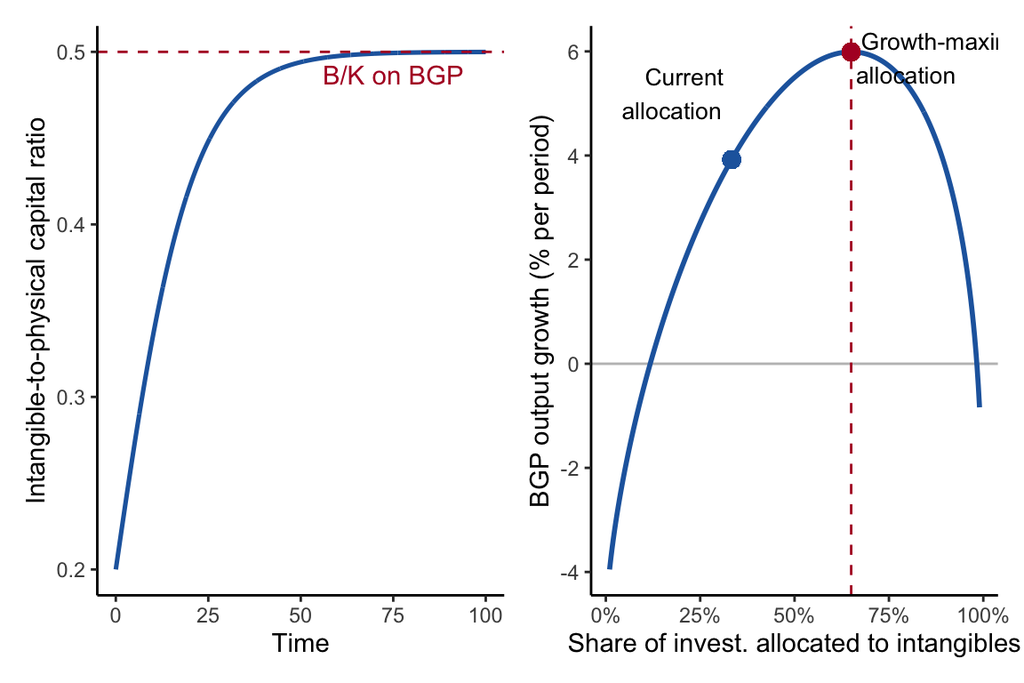

```r
p_ratio <- ggplot(bgp, aes(t, ratio)) +
  geom_line(color = "#2166AC", linewidth = 0.9) +
  geom_hline(yintercept = sB / sK, linetype = "dashed", color = "#B2182B") +
  annotate("text", x = 75, y = 0.95*sB / sK, label = "B/K on BGP",
           color = "#B2182B", vjust = -0.6) +
  theme_classic() +
  labs(x = "Time", y = "Intangible-to-physical capital ratio")

s_total <- sK + sB
theta0 <- sB / s_total
alloc <- tibble(theta = seq(0.01, 0.99, length.out = 300)) |>
  mutate(
    sK_theta = s_total * (1 - theta),
    sB_theta = s_total * theta,
    g = sK_theta * G * L^(1 - alpha) *
        (sB_theta / sK_theta)^eta - delta
  )

g_max <- G * L^(1 - alpha) *
  (s_total * (1 - eta))^alpha * (s_total * eta)^eta - delta

p_growth <- ggplot(alloc, aes(theta, 100 * g)) +
  geom_hline(yintercept = 0, color = "grey75") +
  geom_line(color = "#2166AC", linewidth = 1) +
  geom_vline(xintercept = eta, linetype = "dashed", color = "#B2182B") +
  geom_point(aes(x = theta0, y = 100 * g_bgp),
             inherit.aes = FALSE, color = "#2166AC", size = 3) +
  geom_point(aes(x = eta, y = 100 * g_max),
             inherit.aes = FALSE, color = "#B2182B", size = 3) +
  annotate("text", x = theta0, y = 100 * g_bgp,
           label = "Current\nallocation", hjust = 1.1, vjust = -0.8, size = 3.5) +
  annotate("text", x = eta, y = 100 * g_max*0.9,
           label = "Growth-maximizing\nallocation", hjust = -0.05, vjust = 0, size = 3.5) +
  scale_x_continuous(labels = function(x) paste0(round(100 * x), "%")) +
  theme_classic() +
  labs(x = "Share of invest. allocated to intangibles",
       y = "BGP output growth (% per period)")

p_ratio | p_growth
```